# EDA for P1

Addison McGhee

2021-12-05

```r
injured = read.csv("../../Data/all_injuries_clean.csv") # load data
```

### Select columns

```r
injured = injured %>%
  mutate(short_team_name = fix_nfl_names(full_team), injury = rep(1, nrow(injured))) %>%
  mutate(total_injuries = dplyr::select(injured, head, shoulder, upper_torso, lower_torso, arm, hand, leg, foot) %>% rowSums) %>%
  filter(total_injuries != 0)
```

### Load demographic data

```r
players_dat = read.csv("../../Data/all_player_demographic_clean.csv")

players = players_dat %>%
  mutate(short_team_name = fix_nfl_names(full_team),
         age = age(ymd(birthdate)), bmi = (weight_pounds / height_inches^2)*703) %>%
  mutate(age = age - (2021 - year))
```

### Merge with injury data

```r
injuries = injured %>% left_join(players, by = c("name", "full_team", "short_team_name", "year", "team")) %>%
  filter(position_id != "") %>%
  mutate(injury = factor(injury), position_id = factor(position_id))

players = players %>% left_join(injured, by = c("name", "full_team", "short_team_name", "year", "team")) %>%
  mutate(injury = factor(ifelse(is.na(injury), 0, 1))) %>%
  filter(position_id != "") %>%
  mutate(injury = factor(injury), position_id = factor(position_id))
```

# P1

### Q1: Which positions are most at-risk for injuries? The table below contains descriptive statistics calculated for each position over multiple seasons (2009 - Present).

```r
number_injury = injuries %>%
  group_by(position_id, year) %>%
  count()

number_injury %>% group_by(position_id) %>%
  summarise(mean = mean(n),
            sd = sd(n),
            Q1 = quantile(n, probs = 0.25),
            median = median(n),
            Q3 = quantile(n, probs = 0.75)
  ) %>%
  pander
```

| position_id | mean | sd | Q1 | median | Q3 |
| --- | --- | --- | --- | --- | --- |
| DEF | 511.9 | 130.2 | 413 | 603 | 617 |
| K | 10.38 | 5.009 | 10 | 11 | 12 |
| OL | 192.6 | 40.31 | 180 | 199 | 210 |
| P | 6.769 | 3.7 | 4 | 8 | 10 |
| QB | 32.69 | 12.01 | 24 | 36 | 41 |
| RB | 95.69 | 24.68 | 81 | 107 | 115 |
| TE | 66.85 | 15.79 | 62 | 69 | 77 |
| WR | 130.3 | 25.03 | 116 | 131 | 149 |

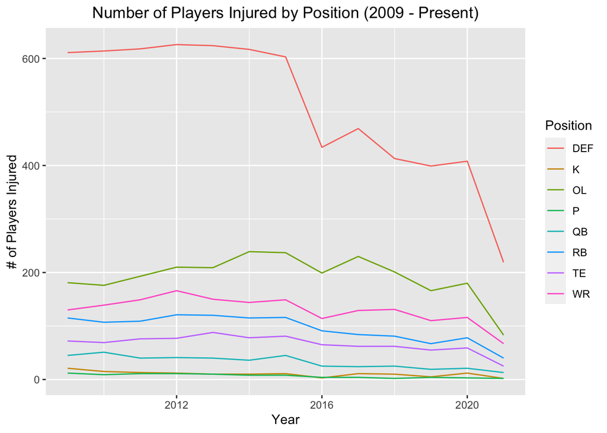

```r
number_injury %>% ggplot(aes(year, n, color = position_id)) +
                    geom_line() +
                    xlab("Year") +
                    ylab("# of Players Injured") +
                    scale_color_discrete(name = "Position") +
                    ggtitle("Number of Players Injured by Position (2009 - Present)")
```

### Maybe a $\log_{10}$ transform could help

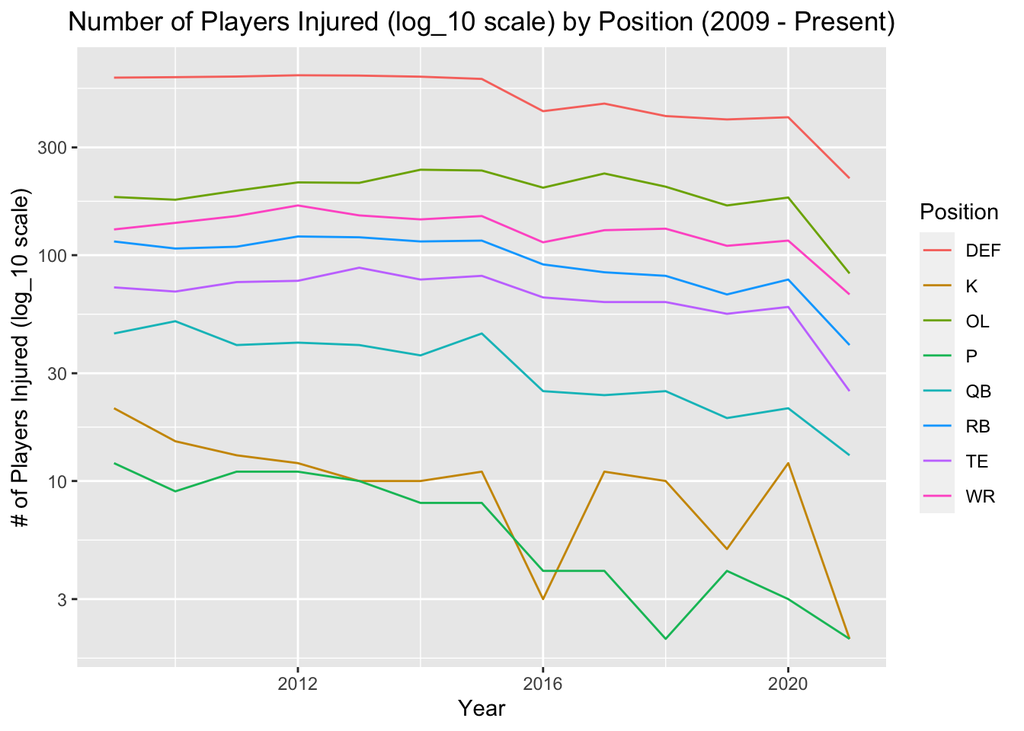

```r
number_injury %>% ggplot(aes(year, n, color = position_id)) +
                    geom_line() +
                    xlab("Year") +
                    ylab("# of Players Injured (log_10 scale)") +
                    scale_color_discrete(name = "Position") +
                    ggtitle("Number of Players Injured (log_10 scale) by Position (2009 - Present)") +
                    scale_y_log10()
```

**if we use this graph, we should adjust for # of players per position**

### What about injuries per year? Is this uniformly distributed?

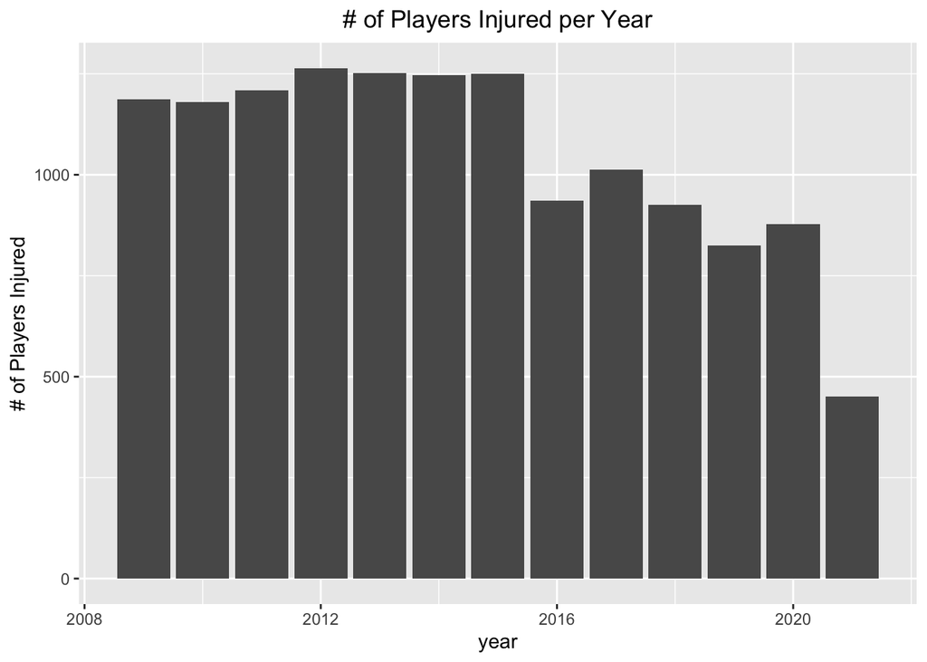

```r
injuries %>% ggplot(aes(year)) +
              geom_bar() +
              ylab("# of Players Injured") +
              ggtitle("# of Players Injured per Year")
```

### Our first step is to check for missing data in our predictors and outcome

```r
#players = players %>%
#  filter(year == 2018)

apply(players %>%
        dplyr::select(injury, position_id, height_inches, weight_pounds, game_starter, age, bmi, year),
      2, function(x) sum(is.na(x))) %>% pander
```

Table continues below

| injury | position_id | height_inches | weight_pounds | game_starter | age |
| --- | --- | --- | --- | --- | --- |
| 0 | 0 | 13 | 11 | 0 | 0 |

| bmi | year |
| --- | --- |
| 13 | 0 |

```r
# remove the 13 people with missing height/weight
players <- players %>%
  drop_na(height_inches)
```

[figure not shown]

```r
players$position_id =
  fct_relevel(players$position_id, c("DEF", "OL", "WR", "RB", "TE", "QB", "K", "P"))

players %>%
  ggplot(aes(position_id, fill = injury)) +
    geom_bar(position = "dodge") +
    xlab("Position") +
    ylab("# of Injured Players") +
    ggtitle("Injured Players by Position in 2018") +
    scale_fill_manual(name = "Injury", guide = guide_legend(reverse=TRUE), values = c("#619CFF", "#F8766D"))
```

**The graph above is very useful for determining whether a logistic regression coefficient would likely be statistically significant. We are looking to see, for a given position, if there is a large discrepancy between the number of injured and non-injured players. If the number of players injured is much larger than the number of non-injured players, then we would expect that the odds of getting injured in this position is large. We would expect the opposite to be the case for a position where the number of non-injured players is much greater than the number of injured players.**

### What is the distribution of BMI for the injured vs non-injured players?

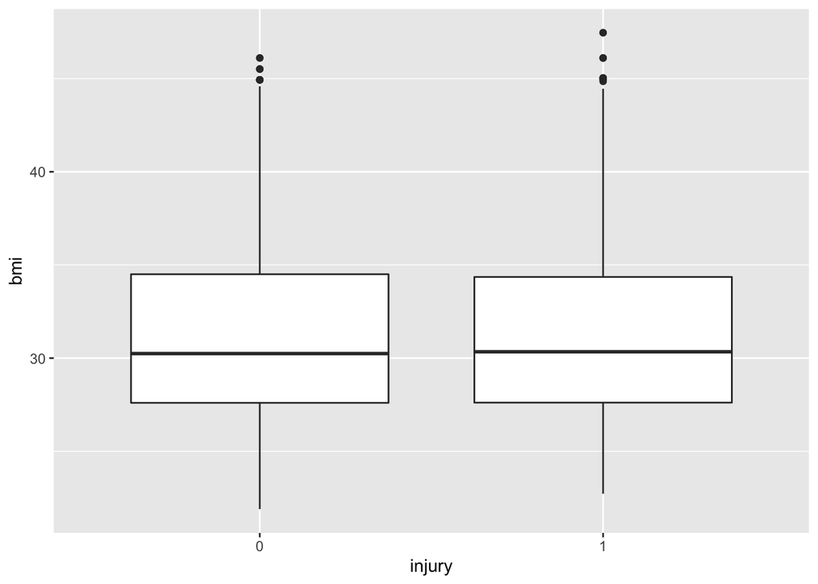

```r
players %>% ggplot(aes(injury, bmi)) +
              geom_boxplot()
```

**The absence of any significant difference between groups suggests that `bmi` will not be a significiant predictor in our Logistic model.**

### What is the distribution of `injury` by `age` in 2018?

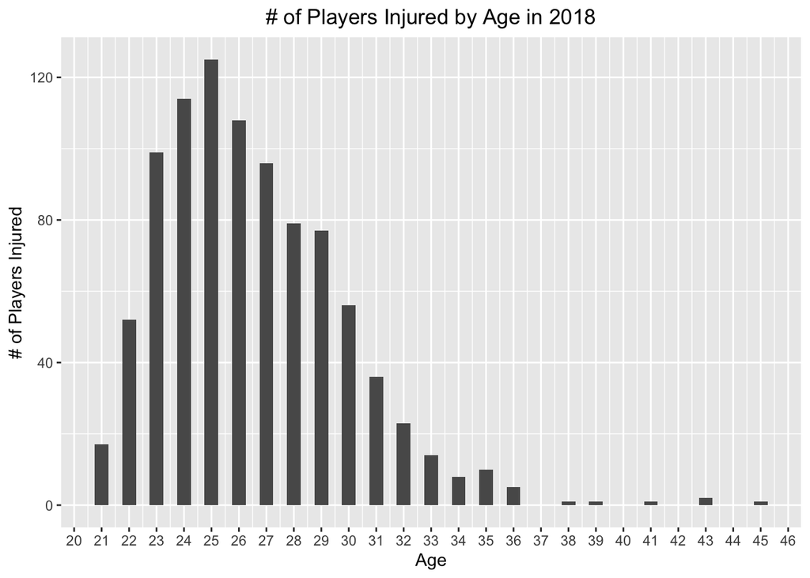

```r
injuries %>% filter(year == 2018) %>%
             ggplot(aes(age)) +
               geom_histogram(binwidth = 0.5) +
               xlab("Age") +
               ylab("# of Players Injured") +
               ggtitle("# of Players Injured by Age in 2018") +
               scale_x_continuous(breaks = seq(0, 50, 1))
```

## Try side by side bars for `age`

[figure not shown]

```r
players %>% ggplot(aes(age, fill = injury)) +
              geom_histogram(binwidth = 0.5, position = "dodge") +
              xlab("Age") +
              ylab("# of Players Injured") +
              ggtitle("# of Injured Players by Age in 2018") +
              scale_x_continuous(breaks = seq(0, 50, 1)) +
              scale_fill_manual(name = "Injury",
                                guide = guide_legend(reverse=TRUE), values = c("#619CFF", "#F8766D"))
```

## Try scaling by number of players in each age group

```r
age_group_size = players %>% group_by(age) %>% count() # get size of each age group

injured_age_group_size = players %>% # get size of age group for injured players only
                          filter(injury == 1) %>%
                          group_by(age) %>%
                          count()

# Some age groups have no injuries, so the vector lengths differ
group_size = age_group_size %>% filter(age %in% injured_age_group_size$age) %>% .$n

injured_age_group_size$scaled_n = injured_age_group_size$n / group_size # Scale by group size
head(injured_age_group_size)
```

```
## # A tibble: 6 x 3
## # Groups:   age [6]
##     age     n scaled_n
##   <dbl> <int>    <dbl>
## 1    20     2    0.667
## 2    21   164    0.519
## 3    22   759    0.46
## 4    23  1544    0.463
## 5    24  1844    0.473
## 6    25  1770    0.493
```

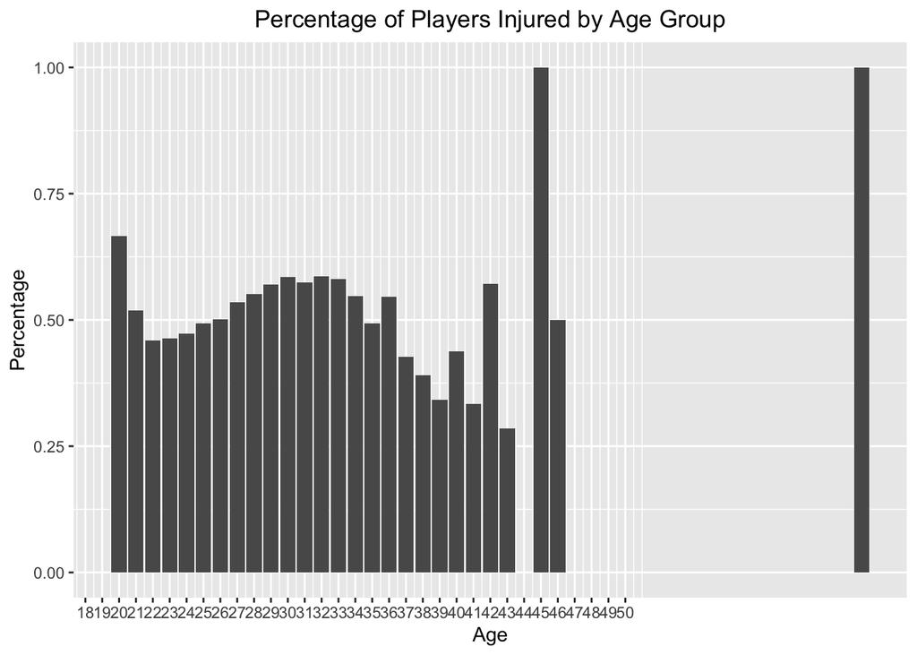

```r
injured_age_group_size %>% ggplot(aes(age, scaled_n)) +
                             geom_col() +
                             xlab("Age") +
                             ylab("Percentage") +
                             ggtitle("Percentage of Players Injured by Age Group") +
                             scale_x_continuous(breaks = seq(0, 50, 1)) +
                             scale_fill_manual(name = "Injury",
                               guide = guide_legend(reverse=TRUE), values = c("#619CFF", "#F8766D"))
```

### Logistic regression (model only; check for significant coefficients)

```r
players = players %>% mutate(position_id = relevel(position_id, ref = "TE"))

logi_fit = glm(data = players, injury ~ position_id + bmi + age, family = binomial())
pander(summary(logi_fit))
```

|  | Estimate | Std. Error | z value | Pr(>\|z\|) |
| --- | --- | --- | --- | --- |
| **(Intercept)** | -1.328 | 0.1512 | -8.782 | 1.601e-18 |
| **position_idDEF** | 0.09244 | 0.05234 | 1.766 | 0.07739 |
| **position_idOL** | -0.0888 | 0.05979 | -1.485 | 0.1375 |
| **position_idWR** | 0.1639 | 0.06251 | 2.622 | 0.008747 |
| **position_idRB** | 0.1582 | 0.06474 | 2.443 | 0.01455 |
| **position_idQB** | -0.4968 | 0.08206 | -6.055 | 1.406e-09 |
| **position_idK** | -1.404 | 0.113 | -12.43 | 1.912e-35 |
| **position_idP** | -1.712 | 0.1296 | -13.22 | 7.067e-40 |
| **bmi** | -0.005606 | 0.003509 | -1.598 | 0.1101 |
| **age** | 0.05922 | 0.003941 | 15.03 | 4.904e-51 |

(Dispersion parameter for binomial family taken to be 1 )

| Null deviance: | 36934 on 26650 degrees of freedom |
| --- | --- |
| Residual deviance: | 36230 on 26641 degrees of freedom |

### The older players could be skewing the results! The odds of getting injured for players above 40 is very high, mainly because there are very players who play at or above this age.

### Let’s remove the players above 40 y/o and see if `age` is still significant

```r
logi_fit2 = glm(data = players %>% filter(age < 40), injury ~ position_id + bmi + age, family = binomial())
pander(summary(logi_fit2))
```

|  | Estimate | Std. Error | z value | Pr(>\|z\|) |
| --- | --- | --- | --- | --- |
| **(Intercept)** | -1.341 | 0.1523 | -8.808 | 1.274e-18 |
| **position_idDEF** | 0.09276 | 0.05235 | 1.772 | 0.07642 |
| **position_idOL** | -0.08949 | 0.0598 | -1.497 | 0.1345 |
| **position_idWR** | 0.1645 | 0.06252 | 2.631 | 0.008521 |
| **position_idRB** | 0.1586 | 0.06475 | 2.449 | 0.01432 |
| **position_idQB** | -0.4935 | 0.08232 | -5.995 | 2.035e-09 |
| **position_idK** | -1.41 | 0.1157 | -12.19 | 3.465e-34 |
| **position_idP** | -1.691 | 0.1301 | -12.99 | 1.307e-38 |
| **bmi** | -0.005538 | 0.00351 | -1.578 | 0.1147 |
| **age** | 0.05965 | 0.004002 | 14.9 | 3.114e-50 |

(Dispersion parameter for binomial family taken to be 1 )

| Null deviance: | 36864 on 26600 degrees of freedom |
| --- | --- |
| Residual deviance: | 36165 on 26591 degrees of freedom |

### Let’s try Quadratic Age, too

```r
players = players %>% mutate(age_sq = age^2)

logi_fit3 = glm(data = players %>% filter(age < 40), injury ~ position_id + bmi + age + age_sq, family = binomial())
pander(summary(logi_fit3))
```

|  | Estimate | Std. Error | z value | Pr(>\|z\|) |
| --- | --- | --- | --- | --- |
| **(Intercept)** | -4.024 | 0.6928 | -5.808 | 6.31e-09 |
| **position_idDEF** | 0.09313 | 0.05236 | 1.779 | 0.07528 |
| **position_idOL** | -0.09081 | 0.0598 | -1.519 | 0.1289 |
| **position_idWR** | 0.1679 | 0.06254 | 2.685 | 0.007262 |
| **position_idRB** | 0.1605 | 0.06478 | 2.478 | 0.01323 |
| **position_idQB** | -0.4712 | 0.08238 | -5.72 | 1.066e-08 |
| **position_idK** | -1.372 | 0.1157 | -11.86 | 1.954e-32 |
| **position_idP** | -1.659 | 0.13 | -12.76 | 2.728e-37 |
| **bmi** | -0.005724 | 0.003512 | -1.63 | 0.1031 |
| **age** | 0.2569 | 0.04985 | 5.154 | 2.55e-07 |
| **age_sq** | -0.003564 | 0.0008974 | -3.972 | 7.131e-05 |

(Dispersion parameter for binomial family taken to be 1 )

| Null deviance: | 36864 on 26600 degrees of freedom |
| --- | --- |
| Residual deviance: | 36149 on 26590 degrees of freedom |

# Machine Learning and Prediction

### Create training and test set

```r
set.seed(1)

x <- stratified(players, "injury", 0.7, keep.rownames = TRUE)
train_set <- x %>% dplyr::select(-rn)
train_index <- as.numeric(x$rn)
test_set <- players[-train_index,]

dim(train_set)
```

```
## [1] 18656    40
```

```r
dim(test_set)
```

```
## [1] 7995   40
```

#### NOTE: Accuracy improved after removing `bmi` as a predictor

### Logistic regression

#### Stepwise model selection to choose best covariates

```r
# baseline logistic regression model (intercept only)
logi_fit_all <- glm(data = players, injury ~ 1, family = binomial())
summary(logi_fit_all)
```

```
##
## Call:
## glm(formula = injury ~ 1, family = binomial(), data = players)
##
## Deviance Residuals:
##    Min      1Q  Median      3Q     Max
##  -1.20   -1.20    1.16    1.16    1.16
##
## Coefficients:
##             Estimate Std. Error z value Pr(>|z|)
## (Intercept)   0.0424     0.0123    3.46  0.00054 ***
## ---
## Signif. codes:  0 '***' 0.001 '**' 0.01 '*' 0.05 '.' 0.1 ' ' 1
##
## (Dispersion parameter for binomial family taken to be 1)
##
##     Null deviance: 36934  on 26650  degrees of freedom
## Residual deviance: 36934  on 26650  degrees of freedom
## AIC: 36936
##
## Number of Fisher Scoring iterations: 3
```

```r
# forward selection
logi_step_fit <- logi_fit_all %>%
  step(direction = "forward", data = players,
       scope = (~ as.factor(position_id) + height_inches + weight_pounds + as.factor(game_starter) +
                  age + I(age^2) + bmi + year))
```

```
## Start:  AIC=36936
## injury ~ 1
##
##                           Df Deviance   AIC
## + as.factor(game_starter)  1    35339 35343
## + year                     1    35722 35726
## + as.factor(position_id)   7    36459 36475
## + age                      1    36832 36836
## + I(age^2)                 1    36845 36849
## + height_inches            1    36923 36927
## <none>                          36934 36936
## + weight_pounds            1    36934 36938
## + bmi                      1    36934 36938
##
## Step:  AIC=35343
## injury ~ as.factor(game_starter)
##
##                          Df Deviance   AIC
## + year                    1    34090 34096
## + as.factor(position_id)  7    34920 34938
## + height_inches           1    35253 35259
## + weight_pounds           1    35277 35283
## + bmi                     1    35306 35312
## + age                     1    35310 35316
## + I(age^2)                1    35314 35320
## <none>                         35339 35343
##
## Step:  AIC=34096
## injury ~ as.factor(game_starter) + year
##
##                          Df Deviance   AIC
## + as.factor(position_id)  7    33676 33696
## + height_inches           1    34012 34020
## + weight_pounds           1    34022 34030
## + bmi                     1    34047 34055
## + age                     1    34073 34081
## + I(age^2)                1    34077 34085
## <none>                         34090 34096
##
## Step:  AIC=33696
```

[output cut: 24 more lines]

```
##
##                 Df Deviance   AIC
## + I(age^2)       1    33562 33588
## <none>                33566 33590
## + bmi            1    33565 33591
## + height_inches  1    33566 33592
##
## Step:  AIC=33588
## injury ~ as.factor(game_starter) + year + as.factor(position_id) +
##     age + weight_pounds + I(age^2)
##
##                 Df Deviance   AIC
## <none>                33562 33588
## + bmi            1    33561 33589
## + height_inches  1    33562 33590
```

```r
summary(logi_step_fit)
```

```
##
## Call:
## glm(formula = injury ~ as.factor(game_starter) + year + as.factor(position_id) +
##     age + weight_pounds + I(age^2), family = binomial(), data = players)
##
## Deviance Residuals:
##    Min      1Q  Median      3Q     Max
## -2.030  -1.074   0.613   1.056   2.245
##
## Coefficients:
##                            Estimate Std. Error z value Pr(>|z|)
## (Intercept)                2.46e+02   7.26e+00   33.94  < 2e-16 ***
## as.factor(game_starter)1   1.03e+00   2.77e-02   37.36  < 2e-16 ***
## year                      -1.23e-01   3.59e-03  -34.34  < 2e-16 ***
## as.factor(position_id)DEF  5.25e-02   5.54e-02    0.95   0.3432
## as.factor(position_id)OL  -1.48e-01   6.21e-02   -2.38   0.0173 *
## as.factor(position_id)WR   1.30e-01   6.74e-02    1.94   0.0529 .
## as.factor(position_id)RB   1.91e-01   6.94e-02    2.75   0.0060 **
## as.factor(position_id)QB  -7.64e-01   8.67e-02   -8.82  < 2e-16 ***
## as.factor(position_id)K   -1.02e+00   1.18e-01   -8.63  < 2e-16 ***
## as.factor(position_id)P   -1.34e+00   1.33e-01  -10.05  < 2e-16 ***
## age                        1.21e-01   4.12e-02    2.94   0.0033 **
## weight_pounds             -2.22e-03   3.84e-04   -5.78  7.5e-09 ***
## I(age^2)                  -1.49e-03   7.32e-04   -2.04   0.0417 *
## ---
## Signif. codes:  0 '***' 0.001 '**' 0.01 '*' 0.05 '.' 0.1 ' ' 1
##
## (Dispersion parameter for binomial family taken to be 1)
##
##     Null deviance: 36934  on 26650  degrees of freedom
## Residual deviance: 33562  on 26638  degrees of freedom
## AIC: 33588
##
## Number of Fisher Scoring iterations: 4
```

#### Now we have our covariates–fit model with training data

```r
logi_fit = glm(data = train_set, family = binomial(),
               injury ~ as.factor(position_id) + weight_pounds + as.factor(game_starter) + age + year)

p_hat_logit = predict(logi_fit, newdata = test_set, type = "response") # get predicted probabilities

y_hat_logit <- as.factor(ifelse(p_hat_logit > 0.5, 1, 0)) # set threshold of 0.5

confusionMatrix(data = y_hat_logit,
                reference = test_set[["injury"]], positive = "1") # generate confusion matrix
```

```
## Confusion Matrix and Statistics
##
##           Reference
## Prediction    0    1
##          0 2347 1324
##          1 1566 2758
##
##                Accuracy : 0.639
##                  95% CI : (0.628, 0.649)
##     No Information Rate : 0.511
##     P-Value [Acc > NIR] : < 2e-16
##
##                   Kappa : 0.276
##
##  Mcnemar's Test P-Value : 7.36e-06
##
##             Sensitivity : 0.676
##             Specificity : 0.600
##          Pos Pred Value : 0.638
##          Neg Pred Value : 0.639
##              Prevalence : 0.511
##          Detection Rate : 0.345
##    Detection Prevalence : 0.541
##       Balanced Accuracy : 0.638
##
##        'Positive' Class : 1
##
```

### k-Nearest Neighbors

#### Use 2-fold cross-validation to find optimal `k` (achieves the highest accuracy for 0.5 cut-off)

```r
set.seed(1)
control <- trainControl(method = 'cv', number = 2, p = .5) # cut-off of 0.5

players2 <- mutate(players, label = injury) %>%
  dplyr::select(label, position_id, age, game_starter, weight_pounds, year)

# res <- train(label ~ .,
#              data = players2,
#              method = "knn",
#              trControl = control,
#              tuneLength = 1, # How fine a mesh to go on grid
#              tuneGrid = data.frame(k = seq(3, 151, 2)),
#              metric = "Accuracy")
#
# res$bestTune # best choice of 'k' is k = 71
# plot(res)
```

```r
knn_fit = knn3(data = train_set, injury ~ as.factor(position_id) + age + as.factor(game_starter) +
                 weight_pounds + year,
               k = 71) # fit kNN using optimal

f_hat_knn = predict(knn_fit, newdata = test_set)[ , 2] # get probability for injury

y_hat_knn = as.factor(ifelse(f_hat_knn > 0.5, 1, 0))

confusionMatrix(data = y_hat_knn,
                reference = test_set$injury, positive = "1") # generate confusion matrix

# plot with 2 dimensions, color = injured vs. not injured to see "neighbors"
players %>%
  ggplot(aes(x = age, y = weight_pounds, color = injury)) +
  geom_point()

players %>%
  ggplot(aes(x = weight_pounds, y = game_starter, color = injury)) +
  geom_point()

players %>%
  ggplot(aes(x = weight_pounds, y = position_id, color = injury)) +
  geom_point()
```

[output not shown]

### Random Forest

```r
rf_fit = randomForest(injury ~ position_id + age + game_starter + weight_pounds + year,
                      data = train_set) # fit random forest using training set

rf_fit

p_hat_rf = predict(rf_fit, newdata = test_set, type = "prob")[,2] # get predicted probabilities

y_hat_rf = as.factor(ifelse(p_hat_rf > 0.5, 1, 0)) # use 0.5 cutoff to get estimates

confusionMatrix(data = y_hat_rf,
                reference = test_set[["injury"]], positive = "1") # generate confusion matrix
```

[output not shown]

### Plot ROCs

```r
roc_logi = roc(test_set[["injury"]], p_hat_logit) # ROC curve creation
roc_knn = roc(test_set[["injury"]], f_hat_knn)
roc_rf = roc(test_set[["injury"]], p_hat_rf)

ggroc(list("Logistic Regression" = roc_logi, "kNN, k = 71" = roc_knn, "Random Forest" = roc_rf)) +
  theme(legend.title = element_blank()) +
  geom_segment(aes(x = 1, xend = 0, y = 0, yend = 1), color = "black", linetype = "dashed") +
  xlab("Sensitivity") +
  ylab("Specificity")
```

[output not shown]

```r
auc(roc_logi) # calculate AUC for each ROC curve
auc(roc_knn)
auc(roc_rf)
```

[output not shown]